# Topic 5 - Transporting & Warehousing

# A. INTRODUCTION ABOUT THE DATA

The transportation industry is responsible for moving goods and people from one place to another, and it plays a vital role in the global economy. We take the stocks from the website [Money CNN](https://money.cnn.com/data/sectors/transportation/), this website provides information on the transportation industry, with a focus on the sub-industry of airlines, the total number of stocks in the transportation sector is 115 stocks.

Then, we take the transportation and warehousing stock data from [Yahoo Finance](https://finance.yahoo.com/), using R. For the transportation stock, there are five main sub-sectors: Air Freight/Couriers, Airlines, Marine Shipping, Railroads and Trucking. The time-frame that we take the stock data is from 01/01/2019 to 03/24/2023

# B. BUILDING THE PORTFOLIO

## 1 Filtering by market cap

First of all, for the method of choosing stocks, we don’t choose penny stocks. The reason we do this is due to some recent challenges associated with investing in low-market cap stocks. More specifically,

- **Market Instability**: In recent times, the stock market has experienced significant volatility due to a variety of factors, including geopolitical tensions, economic uncertainty, and pandemic-related disruptions.
- **Social Media Influence**: The rise of social media has created new challenges for investors, as online platforms can quickly spread rumors, misinformation, and hype surrounding penny stocks. This can lead to inflated share prices and increased volatility, as well as a heightened risk of fraud and scams.
- **Pandemic-Related Disruptions**: The COVID-19 pandemic has caused significant disruptions to the economy, affecting many small and mid-sized companies that often make up the penny stock market. As a result, some penny stocks may be more vulnerable to bankruptcy or other financial difficulties.
- **Economic Uncertainty**: The global economy has faced significant challenges in recent times, with ongoing uncertainty surrounding issues such as trade policy, inflation, and interest rates. This has created a challenging environment for investors, particularly those who are investing in riskier assets such as penny stocks.

Overall, investing in penny stocks can be challenging, particularly in the current economic and regulatory environment. Investors must carefully assess the risks associated with penny stocks and conduct thorough due diligence before making any investment decisions.

As a result, we decided to take the list of five stocks that have the highest market capitalization in each sub sector of the transportation industry. Choosing the top 5 market cap from each sub sector instead of choosing directly the top 30 from the entire data in the industry is because we want to make the portfolio more diversified.

```r
# Sorting firms by market cap ####
afc <- read.delim('D:/quang/doc/AFC Transporting.txt',
                       header=FALSE)
a <- read.delim('D:/quang/doc/Airline Transporting.txt',
                  header=FALSE)
ms <- read.delim('D:/quang/doc/MS Transporting.txt',
                  header=FALSE)
rr <- read.delim('D:/quang/doc/RR Transporting.txt',
                  header=FALSE)
t <- read.delim('D:/quang/doc/Trucking Transporting.txt',
                  header=FALSE)
## define custom function to convert market cap string to number
convert_market_cap <- function(x) {
  if (substr(x, nchar(x), nchar(x)) == "T") {
    return(as.numeric(substr(x, 2, nchar(x)-1)) * 1000000000000)
  } else if (substr(x, nchar(x), nchar(x)) == "B") {
    return(as.numeric(substr(x, 2, nchar(x)-1)) * 1000000000)
  } else if (substr(x, nchar(x), nchar(x)) == "M") {
    return(as.numeric(substr(x, 2, nchar(x)-1)) * 1000000)
  } else if (substr(x, nchar(x), nchar(x)) == "K") {
    return(as.numeric(substr(x, 2, nchar(x)-1)) * 1000)
  } else {
    return(NA)
  }
}
top_5_market_cap <- function(x) {
  x$V2 <- sapply(x$V2, convert_market_cap)
  x <- x[order(-x$V2), ][1:5, c("V1", "V2")]
  colnames(x) <- c("Tickers", "Market Cap")
  return(x)
}
```

```r
top_5_market_cap(a)
```

```
##                      Tickers  Market Cap
## 9        DAL Delta Air Lines 20300000000
## 18    LUV Southwest Airlines 17600000000
## 4      AAL American Airlines  8900000000
## 2   ALK Alaska Air Group Inc  4900000000
## 14 JBLU JetBlue Airways Corp  2200000000
```

```r
top_5_market_cap(afc)
```

```
##                                            Tickers   Market Cap
## 19                                         UPS UPS 134500000000
## 5                                        FDX FedEx  54700000000
## 4  EXPD Expeditors International of Washington Inc  16100000000
## 2                   CHRW CH Robinson Worldwide Inc  11000000000
## 6                               HUBG Hub Group Inc   2700000000
```

```r
top_5_market_cap(ms)
```

```
##                           Tickers Market Cap
## 6                  KEX Kirby Corp 4000000000
## 5  INSW International Seaways Inc 2100000000
## 7                 MATX Matson Inc 2100000000
## 11              TDW Tidewater Inc 2000000000
## 1              LPG Dorian LPG Ltd  834000000
```

```r
top_5_market_cap(t)
```

```
##                                         Tickers  Market Cap
## 17           ODFL Old Dominion Freight Line Inc 36300000000
## 11         JBHT J B Hunt Transport Services Inc 17200000000
## 12 KNX Knight-Swift Transportation Holdings Inc  8900000000
## 13                     LSTR Landstar System Inc  6200000000
## 8                         FWRD Forward Air Corp  3000000000
```

```r
top_5_market_cap(rr)
```

```
##                                 Tickers   Market Cap
## 4                     UNP Union Pacific 115300000000
## 1                          CSX CSX Corp  58300000000
## 3                  NSC Norfolk Southern  45600000000
## 2                        GATX GATX Corp   3700000000
## 5 AWRY Allegheny and Western Railway Co      2700000
```

Therefore,

- the top 5 market cap stocks in Airline are: DAL, LUV, AAL, ALK, JBLU
- the top 5 market cap stocks in Air-Fright Courier are: UPS, FDX, EXPD, CHRW, HUBG
- the top 5 market cap stocks in Marine-Shipping are: KEX, INSWL, MATX, TDW, LPG
- the top 5 market cap stocks in Trucking are: ODFL, JBHT, KNX, LSTR, FWRD
- the top 5 market cap stocks in Railroad are: UNP, CSX, NSC, GATX, AWRY

Stocks whose correlation is **less than 0.6** will be kept, to ensure the diversity of the portfolio. In the case of stocks in highly correlated sub-sectors, we take the stock with the highest market cap.

## 2 Filtering by correlation

### Airline Stock

the top 5 market cap stocks in Airline: *DAL, LUV, AAL, ALK, JBLU*

```r
symbolsA=c('DAL','LUV','AAL',
          'ALK','JBLU')

getSymbols(symbolsA, src = "yahoo",
           from = "2019-01-01", to = "2023-03-24")
```

```
## [1] "DAL"  "LUV"  "AAL"  "ALK"  "JBLU"
```

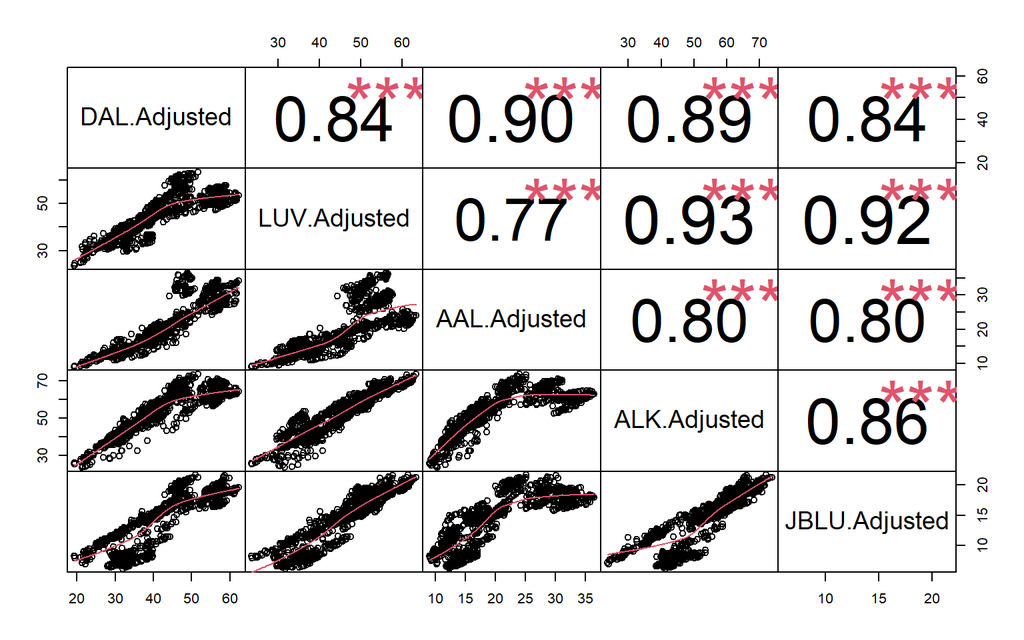

```r
dataA <- merge(DAL$DAL.Adjusted, LUV$LUV.Adjusted,AAL$AAL.Adjusted, ALK$ALK.Adjusted,
              JBLU$JBLU.Adjusted)

chart.Correlation(dataA,
                  histogram = FALSE,
                  pch = "+")
```

After examination, these stocks are highly correlated, so we take one of them. We will take the one with the highest market cap. *DAL* is chosen

### Air Freight/ Couriers stocks testing

the top 5 market cap stocks in Air-Fright Courier are: *UPS, FDX, EXPD, CHRW, HUBG*

```r
symbolsAFC=c('UPS','FDX','EXPD','CHRW','HUBG')

getSymbols(symbolsAFC, src = "yahoo",
           from = "2019-01-01", to = "2023-03-24")
```

```
## [1] "UPS"  "FDX"  "EXPD" "CHRW" "HUBG"
```

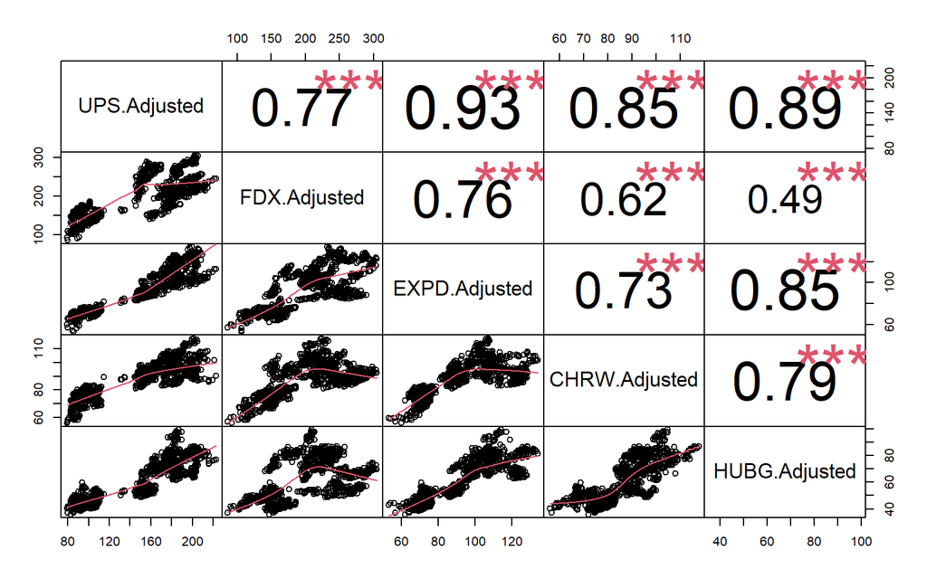

```r
dataAFC <- merge(UPS$UPS.Adjusted, FDX$FDX.Adjusted, EXPD$EXPD.Adjusted,
                 CHRW$CHRW.Adjusted, HUBG$HUBG.Adjusted)

chart.Correlation(dataAFC,
                  histogram = FALSE,
                  pch = "+")
```

Since all stocks have high correlation, only correlation between FDX and HUBG is 0.49 smaller than 0.6. So, we take *FDX, HUBG*.

### Marine Shipping stocks testing

The top 5 market cap stocks in Marine-Shipping: **KEX, INSWL, MATX, TDW, LPG**

```r
symbolsMS=c('KEX','INSW', 'MATX','TDW','LPG')

getSymbols(symbolsMS, src = "yahoo",
           from = "2019-01-01", to = "2023-03-24")
```

```
## [1] "KEX"  "INSW" "MATX" "TDW"  "LPG"
```

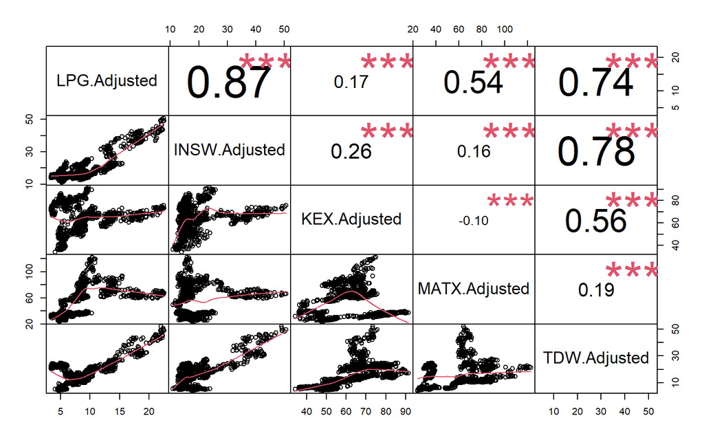

```r
dataMS <- merge(LPG$LPG.Adjusted,INSW$INSW.Adjusted, KEX$KEX.Adjusted,
                MATX$MATX.Adjusted,TDW$TDW.Adjusted )

chart.Correlation(dataMS,
                  histogram = FALSE,
                  pch = "+")
```

After filtering the stocks by its correlation, only three stocks INSW, KEX, MATX are not highly correlated. Then, stocks that we choose are *INSW, KEX, MATX*.

### Trucking stock testing

The top 5 market cap stocks in Trucking: *ODFL, JBHT, KNX, LSTR, FWRD*

```r
symbolT=c('ODFL','JBHT','KNX', 'LSTR','FWRD')

getSymbols(symbolT, src = "yahoo",
           from = "2019-01-01", to = "2023-03-24")
```

```
## [1] "ODFL" "JBHT" "KNX"  "LSTR" "FWRD"
```

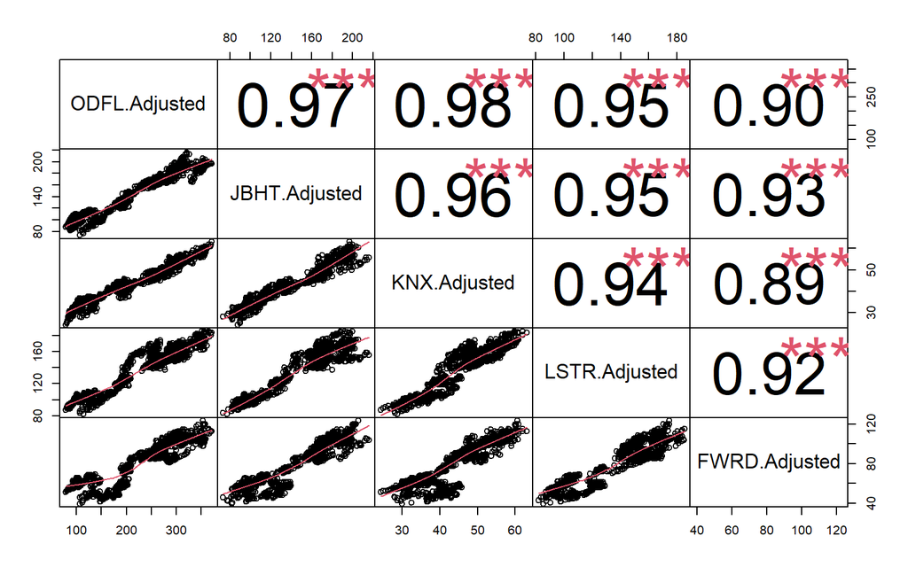

```r
dataT=merge(ODFL$ODFL.Adjusted, JBHT$JBHT.Adjusted, KNX$KNX.Adjusted,
            LSTR$LSTR.Adjusted, FWRD$FWRD.Adjusted)

chart.Correlation(dataT,histogram = FALSE, pch="+")
```

All stocks in this sub sector are highly correlated. The one with the highest market cap should be chosen so we take *ODFL*.

### Railroad stock testing

The top 5 market cap stocks in Railroad: *UNP, CSX, NSC, GATX, AWRY*. However, since AWRY lacks a lot of data, we remove it from the list.

```r
symbolRR=c('UNP', 'CSX', 'NSC', 'GATX')
getSymbols(symbolRR, src = "yahoo",
           from = "2019-01-01", to = "2023-03-24")
```

```
## [1] "UNP"  "CSX"  "NSC"  "GATX"
```

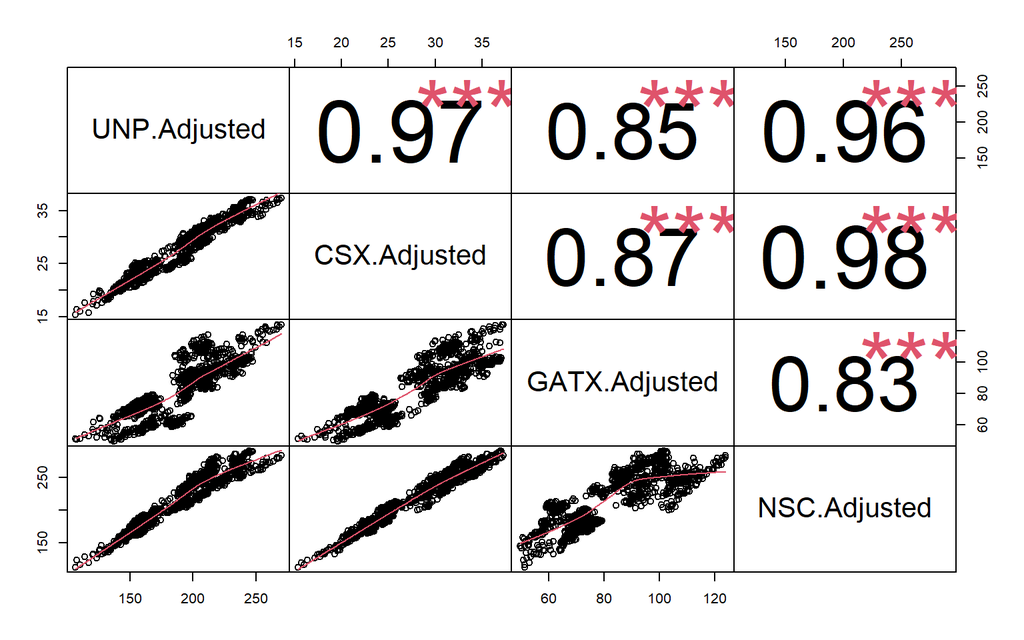

```r
dataRR=merge(UNP$UNP.Adjusted, CSX$CSX.Adjusted, GATX$GATX.Adjusted,
                NSC$NSC.Adjusted)

chart.Correlation(dataRR, histogram = FALSE, pch = "+")
```

After filtering the stocks by its correlation, all stocks are highly correlated, so we choose the one with highest market cap. Therefore, *UNP* is chosen.

### Warehousing stocks testing

```r
symbolW=c('DPW.DE','R','CEVA','COLD','ILPT')
getSymbols(symbolW, src = "yahoo",
           from = "2019-01-01", to = "2023-03-24")
```

```
## [1] "DPW.DE" "R"      "CEVA"   "COLD"   "ILPT"
```

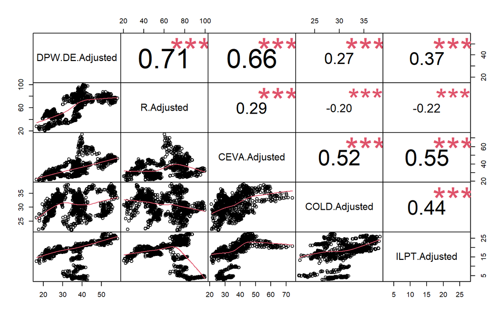

```r
dataW=merge(DPW.DE$DPW.DE.Adjusted,R$R.Adjusted,
            CEVA$CEVA.Adjusted,COLD$COLD.Adjusted,
            ILPT$ILPT.Adjusted)

chart.Correlation(dataW, histogram = FALSE, pch="+")
```

After filtering the stocks, except for stock DPW.DE having correlation with R and CEVA higher than 0.6, the rest stocks have weak correlations with each other, so we can take *R, CEVA, COLD, ILPT*.

### **Total tickers correlation testing**

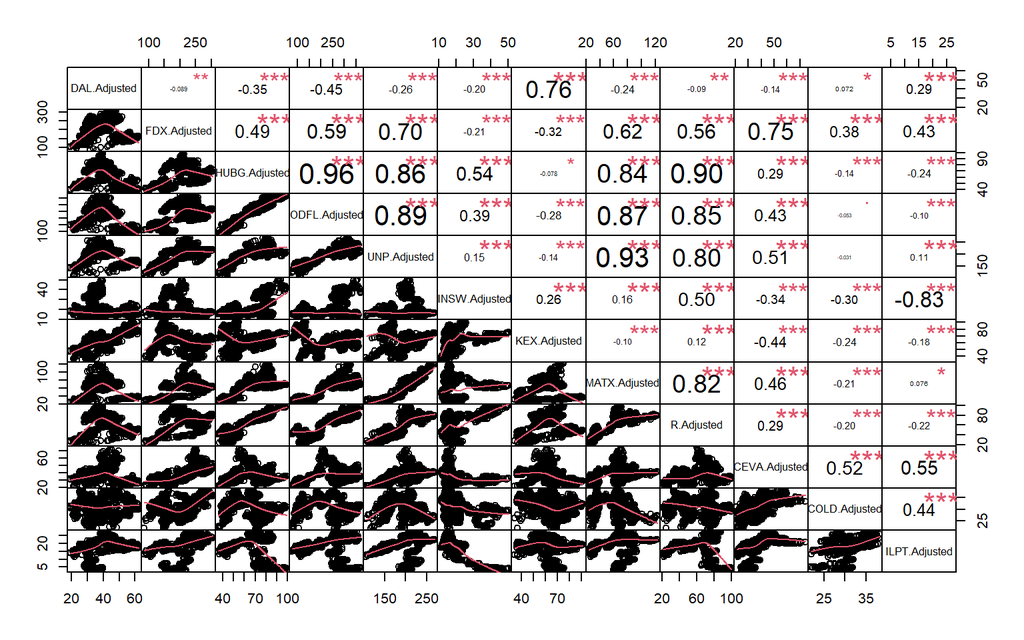

```r
g1 = merge(DAL$DAL.Adjusted,FDX$FDX.Adjusted,HUBG$HUBG.Adjusted,
         ODFL$ODFL.Adjusted,UNP$UNP.Adjusted,
         INSW$INSW.Adjusted,KEX$KEX.Adjusted,MATX$MATX.Adjusted,
         R$R.Adjusted, CEVA$CEVA.Adjusted, COLD$COLD.Adjusted,
         ILPT$ILPT.Adjusted)

chart.Correlation(g1,histogram = FALSE, pch="+")
```

Finally, we have our portfolio to optimize: *FDX, INSW, KEX, R, COLD*.

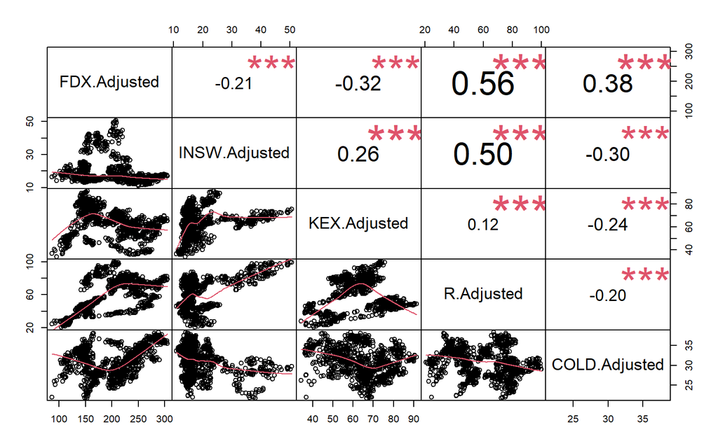

```r
final_tickers =merge(FDX$FDX.Adjusted,INSW$INSW.Adjusted,KEX$KEX.Adjusted,
             R$R.Adjusted, COLD$COLD.Adjusted)

chart.Correlation(final_tickers,histogram = FALSE, pch="+")
```

> FINAL DATA: FDX, INSW, KEX, R, COLD

# C. EXPLORATORY DATA ANALYSIS

## 1. ChartSeries Analysis

*ChartSeries Explanation*

**The relative strength index (RSI)** is a momentum indicator used in technical analysis. RSI measures the speed and magnitude of a security’s recent price changes to evaluate overvalued or undervalued conditions in the price of that security. The RSI is displayed as an oscillator (a line graph) on a scale of zero to 100. The indicator was developed by J. Welles Wilder Jr. and introduced in his seminal 1978 book, New Concepts in Technical Trading Systems. The RSI can do more than point to overbought and oversold securities. It can also indicate securities that may be primed for a trend reversal or corrective pullback in price. It can signal when to buy and sell. Traditionally, an RSI reading of 70 or above indicates an overbought situation. A reading of 30 or below indicates an oversold condition.

**Moving averages** are one of the core indicators in technical analysis, and there are a variety of different versions. **SMA(Simple Moving Average)** is the easiest moving average to construct. It is simply the average price over the specified period. The average is called “moving” because it is plotted on the chart bar by bar, forming a line that moves along the chart as the average value changes.

SMAs are often used to determine trend direction. If the SMA is moving up, the trend is up. If the SMA is moving down, the trend is down. A 200-bar SMA is common proxy for the long term trend. 50-bar SMAs are typically used to gauge the intermediate trend. Shorter period SMAs can be used to determine shorter term trends. SMAs are commonly used to smooth price data and technical indicators. The longer the period of the SMA, the smoother the result, but the more lag that is introduced between the SMA and the source. Price crossing SMA is often used to trigger trading signals. When prices cross above the SMA, you might want to go long or cover short; when they cross below the SMA, you might want to go short or exit long. SMA Crossing SMA is another common trading signal. When a short period SMA crosses above a long period SMA, you may want to go long. You may want to go short when the short-term SMA crosses back below the long-term SMA

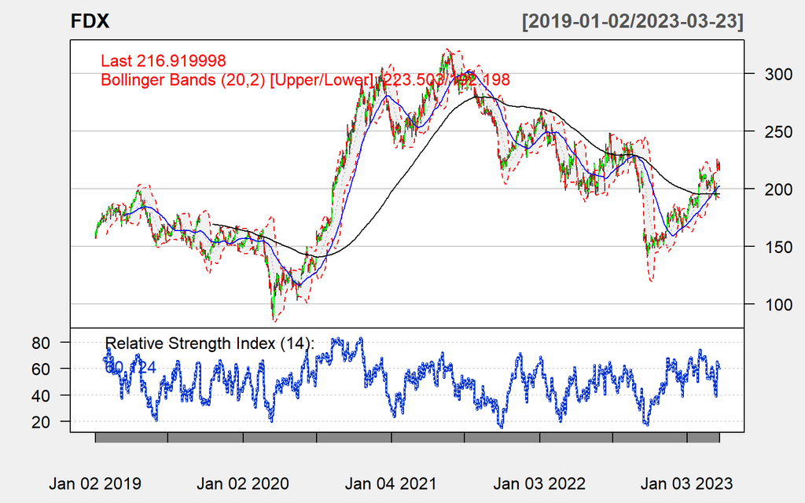

```r
chartSeries(FDX,
            theme=chartTheme('white',up.col='green',dn.col='red'),
            TA=c(addBBands(n=20,sd=2,),
                 addSMA(n=50,col="blue"),
                 addSMA(n=200,col="black"),
                 addRSI(n=14)))
```

```r
FDXc <- FDX[,c(1:4)] # Remove Volume and Adjusted
FDXc$SMA50 <- SMA(Cl(FDXc), n = 50) #create SMA50 line
FDXc$SMA200 <- SMA(Cl(FDXc), n = 200)

dygraph(FDXc, xlab = "Date", ylab = "Price", main = "FDX Price") %>%
dySeries("FDX.Open", label = "Open", color = "#FFE15D" ) %>%
dySeries("FDX.Low", label = "Low", color = "#F49D1A") %>%
dySeries("FDX.High", label = "High", color = "#DC3535") %>%
dySeries("FDX.Close", label = "Close", color = "#B01E68") %>%
dySeries("SMA50", label = "SMA50", color = "blue") %>%
dySeries("SMA200", label = "SMA200", color = "purple") %>%
dyRangeSelector() %>%
dyCandlestick()%>%
dyCrosshair(direction = "vertical") %>%
dyHighlight(highlightCircleSize = 3, highlightSeriesBackgroundAlpha = 0.2, hideOnMouseOut = T)  %>%
dyRoller(rollPeriod = 1)
```

[interactive chart not shown]

Through the use of the Bollinger band, we can clearly see that the FDX stock has undergone brief periods of sharp fluctuations between 2019 and the present. Investors who plan to hold this stock for a long time should therefore carefully consider. If the stock experienced a narrow Bollinger band in 2019 indicating an explosive period with fast and significant price fluctuations, then the candlestick chart line has documented the phenomenon of breaking the band in 2020. Prices increased as a result in 2020 and 21. Going into 2022, FDX observed a downward trend in its stock price, which peaked in the middle of the year. However, when looking at the chart, the candlestick chart of the most recent period has shown signs of crossing the SMA50 and SMA200 lines above, showing the stock price is gradually increasing. The stock price has also shown signs of recovering immediately after the bottom.

Investors should invest in the stock now because it is moving strongly and the bullish candlestick chart has frequently been close to the upper border of the Bollinger Band, followed by a period of the chart that was close to the lower border of the Bollinger Band. Investors can profit with their fixed profit variation during the oversold period, as indicated by the Bollinger Band, which signals a cycle of overbought and oversold conditions. In addition, the chart shows that the SMA50 line rises and crosses the SMA200 line in the first quarter of 2023, which is a positive sign that investors should purchase FDX stock.

### b. INSW

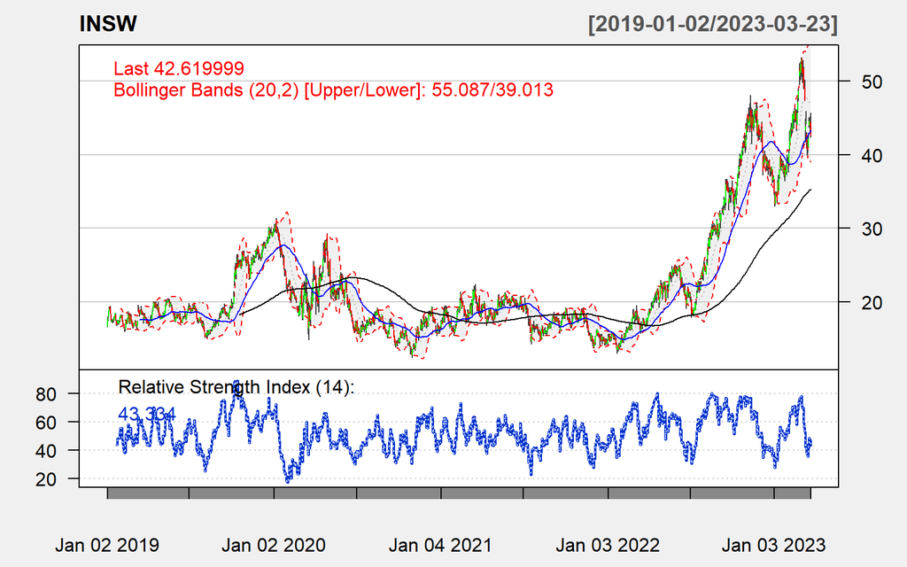

```r
chartSeries(INSW,
            theme=chartTheme('white',up.col='green',dn.col='red'),
            TA=c(addBBands(n=20,sd=2,),
                 addSMA(n=50,col="blue"),
                 addSMA(n=200,col="black"),
                 addRSI(n=14)))
```

```r
INSWc <- INSW[,c(1:4)] # Remove Volume and Adjusted
INSWc$SMA50 <- SMA(Cl(INSWc), n = 50) #create SMA50 line
INSWc$SMA200 <- SMA(Cl(INSWc), n = 200)

dygraph(INSWc, xlab = "Date", ylab = "Price", main = "INSW Price") %>%
dySeries("INSW.Open", label = "Open", color = "#FFE15D" ) %>%
dySeries("INSW.Low", label = "Low", color = "#F49D1A") %>%
dySeries("INSW.High", label = "High", color = "#DC3535") %>%
dySeries("INSW.Close", label = "Close", color = "#B01E68") %>%
dySeries("SMA50", label = "SMA50", color = "blue") %>%
dySeries("SMA200", label = "SMA200", color = "purple") %>%
dyRangeSelector() %>%
dyCandlestick()%>%
dyCrosshair(direction = "vertical") %>%
dyHighlight(highlightCircleSize = 3, highlightSeriesBackgroundAlpha = 0.2, hideOnMouseOut = T)  %>%
dyRoller(rollPeriod = 1)
```

[interactive chart not shown]

In addition, given that the short-term SMA is rising and crossing the long-term SMA, it is advisable for investors to think about purchasing INSW stocks at this time. As a result, we can say that the company is performing well and offers a good long-term investment. When deciding whether to invest in INSW, we should also take the RSI into consideration.We can see from the chart that this stock’s RSI fluctuates quite a bit. Overbought and oversold market cycles have been common in the past and could happen again today. From there, during the stock’s oversold period, short-term investors can fully profit with a fixed profit margin.

### c. KEX

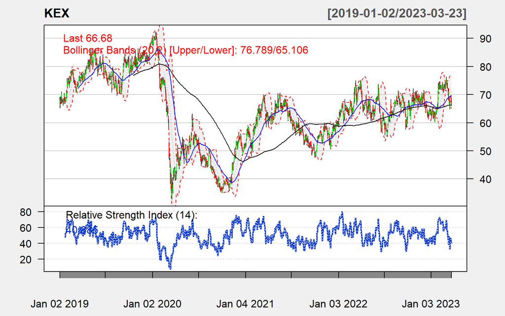

```r
chartSeries(KEX,
            theme=chartTheme('white',up.col='green',dn.col='red'),
            TA=c(addBBands(n=20,sd=2,),
                 addSMA(n=50,col="blue"),
                 addSMA(n=200,col="black"),
                 addRSI(n=14)))
```

```r
KEXc <- KEX[,c(1:4)] # Remove Volume and Adjusted
KEXc$SMA50 <- SMA(Cl(KEXc), n = 50) #create SMA50 line
KEXc$SMA200 <- SMA(Cl(KEXc), n = 200)

dygraph(KEXc, xlab = "Date", ylab = "Price", main = "KEX Price") %>%
dySeries("KEX.Open", label = "Open", color = "#FFE15D" ) %>%
dySeries("KEX.Low", label = "Low", color = "#F49D1A") %>%
dySeries("KEX.High", label = "High", color = "#DC3535") %>%
dySeries("KEX.Close", label = "Close", color = "#B01E68") %>%
dySeries("SMA50", label = "SMA50", color = "blue") %>%
dySeries("SMA200", label = "SMA200", color = "purple") %>%
dyRangeSelector() %>%
dyCandlestick()%>%
dyCrosshair(direction = "vertical") %>%
dyHighlight(highlightCircleSize = 3, highlightSeriesBackgroundAlpha = 0.2, hideOnMouseOut = T)  %>%
dyRoller(rollPeriod = 1)
```

[interactive chart not shown]

Despite its subtle fluctuations from 2019 to the present, the stock ticker KEX is also a stock worth investing in. The candlestick chart crossing above the two SMA50 and SMA200 lines typically signals a significant increase in the stock price from 2019 to the beginning of 2020. However, in the middle of 2020, as a result of the pandemic situation and the impact of the economy, the price of KEX stock abruptly decreased in the second half of 2020. Notably, this is the period when the index declined.

The RSI also abruptly dropped to 7.33 in March 2020, indicating that the stock is oversold, the price has bottomed out, and a price correction is necessary before the price can rise once more. Because of this, the stock’s price started to recover strongly at the beginning of 2021 and has continued to grow steadily ever since. This is encouraging news for investors who plan to hold onto this stock for a while. In addition, buying KEX stock could be a wise move when in the current period, the SMA50 rising and maintaining the trend above the SMA200 . Furthermore, when examining the chart, we can see that the candlestick chart line frequently crosses the border in the current period, indicating a period of explosive price growth for the KEX stock. As a result, this is another option worth noting for investors with immediate investment needs because they can take into account modifying their trading in order to generate profits for themselves.

### d. R

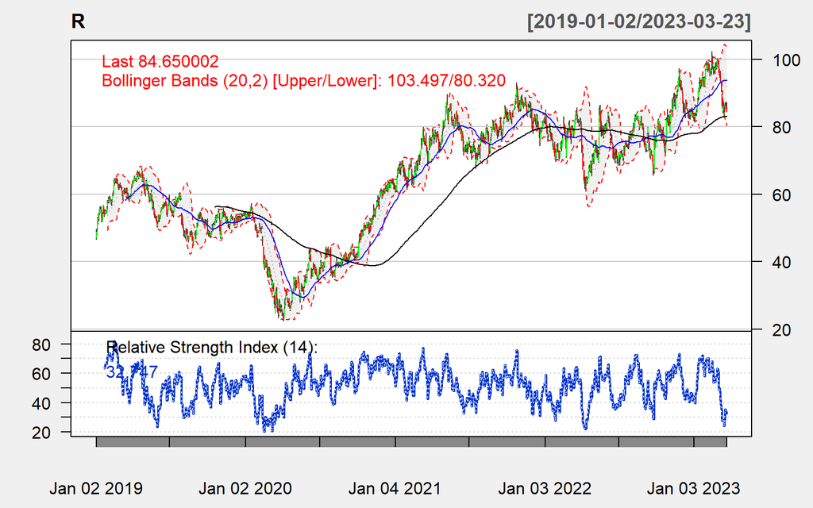

```r
chartSeries(R,
            theme=chartTheme('white',up.col='green',dn.col='red'),
            TA=c(addBBands(n=20,sd=2,),
                 addSMA(n=50,col="blue"),
                 addSMA(n=200,col="black"),
                 addRSI(n=14)))
```

```r
Ra <- R[,c(1:4)] # Remove Volume and Adjusted
Ra$SMA50 <- SMA(Cl(Ra), n = 50) #create SMA50 line
Ra$SMA200 <- SMA(Cl(Ra), n = 200)

dygraph(Ra, xlab = "Date", ylab = "Price", main = "R Price") %>%
dySeries("R.Open", label = "Open", color = "#FFE15D" ) %>%
dySeries("R.Low", label = "Low", color = "#F49D1A") %>%
dySeries("R.High", label = "High", color = "#DC3535") %>%
dySeries("R.Close", label = "Close", color = "#B01E68") %>%
dySeries("SMA50", label = "SMA50", color = "blue") %>%
dySeries("SMA200", label = "SMA200", color = "purple") %>%
dyRangeSelector() %>%
dyCandlestick()%>%
dyCrosshair(direction = "vertical") %>%
dyHighlight(highlightCircleSize = 3, highlightSeriesBackgroundAlpha = 0.2, hideOnMouseOut = T)  %>%
dyRoller(rollPeriod = 1)
```

[interactive chart not shown]

As mentioned, SMA is the most basic tool for technical analysis of stocks. By analyzing SMA, we can consider what time is the best for going long or short. The behavior of an indicator is unique in all uptrend market conditions. For the case of R price, with data collected in a 4 year period, it is important to evaluate the SMA200 which tells more about the long-term position of the stock. We start our evaluation from Q4 of 2019: SMA50 remained below SMA200 in October 2019, as the price opened at 52.19 and closed at 48.44.

SMA50 was 50.72 and SMA200 was 56.27, according to the data. In this situation, you could take a short position to be safe. The long-term SMA was higher than the short-term SMA at that time, and it also had a slightly negative trend. The price point went above two SMA lines at that precise instant. In fact, it was forecast to see a consistent upward trend until the globe experienced COVID19 in the first quarter of 2020, which caused the price to halve in just two months. It dropped to 23.4 in March 2020 from a peak of 56.7 in January 2020. However, two SMA lines still gave a positive signal, after that tragic period, the price kept increasing steadily. While SMA50 plummeted, SMA200 only dropped slightly. As a result, the price bottomed out in April 2020, the stock’s price started to recover strongly from that to the beginning of 2021 and has continued to grow steadily ever since. For investors who intend to stay onto this stock for a while, this is excellent news. Also, purchasing R stock may be a smart option given that the SMA50 line is increasing and sustaining its trend above the SMA200 line at the moment.

As for RSI analysis, R stock is more likely to be overbought than oversold. It is also worth noting that the overbought and oversold cycle of R stock occurs only at its peaks, which is quite normal in the stock market. In general, Ryder System stock is still worth investing in because it is price stable, high value, and profitable in the long run.

### e. COLD

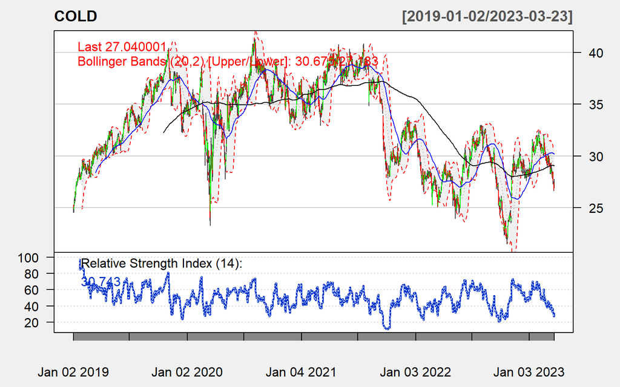

```r
chartSeries(COLD,
            theme=chartTheme('white',up.col='green',dn.col='red'),
            TA=c(addBBands(n=20,sd=2,),
                 addSMA(n=50,col="blue"),
                 addSMA(n=200,col="black"),
                 addRSI(n=14)))
```

```r
COLDa <- COLD[,c(1:4)] # Remove Volume and Adjusted
COLDa$SMA50 <- SMA(Cl(COLDa), n = 50) #create SMA50 line
COLDa$SMA200 <- SMA(Cl(COLDa), n = 200)

dygraph(COLDa, xlab = "Date", ylab = "Price", main = "COLD Price") %>%
dySeries("COLD.Open", label = "Open", color = "#FFE15D" ) %>%
dySeries("COLD.Low", label = "Low", color = "#F49D1A") %>%
dySeries("COLD.High", label = "High", color = "#DC3535") %>%
dySeries("COLD.Close", label = "Close", color = "#B01E68") %>%
dySeries("SMA50", label = "SMA50", color = "blue") %>%
dySeries("SMA200", label = "SMA200", color = "purple") %>%
dyRangeSelector() %>%
dyCandlestick()%>%
dyCrosshair(direction = "vertical") %>%
dyHighlight(highlightCircleSize = 3, highlightSeriesBackgroundAlpha = 0.2, hideOnMouseOut = T)  %>%
dyRoller(rollPeriod = 1)
```

[interactive chart not shown]

As for the stock price of COLD, with data collected over a 4 year period, we can tell people seem to be coming out and selling the COLD stock. Volume based technical analysis of COLD stock is negative. Americold Logistic Stock is giving positive returns over a short-term period, returns for a longer term period have been negative. It can be told by looking at SMA moving averages of Americold Logistic COLD, the SMA 50 line remained its position below the SMA 200 for a quite long period, from September 2021 to July 2022. Looking at the exhibition, we can tell COLD stock prices are extremely fluctuated, it changes almost every month.

Also, COLD stock’s RSI overbought and oversold cycles have occurred in more oversold condition than overbought. At some point, RSI even went below 20 in the Q4 of 2021, indicating it was oversold. The price at that time was not even the lowest so far. However, looking at two SMA lines, it was reasonable for COLD stockholders to go in a short position. SMA 50 crossed far below SMA 200 with a downward trend until mid-2022. Short-term investors can then profit fully during COLD stock’s oversold period in 2021 because after that, the price started to recover quite significantly before another plunge occurred. In conclusion, we can say that Americold Logistics offers a tempting short-term investment. However, when deciding whether to invest in COLD in the long-run, investors should also take the RSI into consideration.

## 2. Descriptive Statistics

### a. Statistics for adjusted price

#### Overall statistics for stocks

```r
# FDX, INSW, KEX, R, COLD
# Take adjusted price
FDXad = FDX$FDX.Adjusted;
INSWad = INSW$INSW.Adjusted;
KEXad = KEX$KEX.Adjusted;
Rad = R$R.Adjusted;
COLDad = COLD$COLD.Adjusted;
adReturnDat <- merge(FDXad, INSWad, KEXad, Rad, COLDad)
basicStats(adReturnDat)
```

```
##              FDX.Adjusted INSW.Adjusted KEX.Adjusted   R.Adjusted COLD.Adjusted
## nobs          1064.000000   1064.000000  1064.000000  1064.000000   1064.000000
## NAs              0.000000      0.000000     0.000000     0.000000      0.000000
## Minimum         86.333694     10.956187    34.200001    20.575254     21.764475
## Maximum        304.875916     50.651600    91.430000    99.820000     38.267227
## 1. Quartile    153.620403     14.788356    55.467500    46.088025     28.086710
## 3. Quartile    240.990677     20.815326    73.169998    76.589630     33.717813
## Mean           198.931773     19.594760    63.970395    61.003844     30.873983
## Median         200.606781     16.338640    64.559998    62.934466     30.921696
## Sum         211663.406079  20848.824367 68064.499990 64908.089958  32849.917478
## SE Mean          1.569464      0.245528     0.377200     0.569715      0.110710
## LCL Mean       195.852174     19.112986    63.230255    59.885950     30.656747
## UCL Mean       202.011371     20.076534    64.710535    62.121738     31.091218
## Variance      2620.862201     64.142015   151.385369   345.348380     13.041200
## Stdev           51.194357      8.008871    12.303876    18.583551      3.611260
## Skewness         0.140505      1.882089    -0.174411    -0.102154     -0.100085
## Kurtosis        -1.080046      2.675242    -0.506041    -1.057990     -0.771117
```

We explain the terms in the table of basicStats that are not immediately clear:

nobs is the number of observations; Sum is the sum of all nobs observations (hence, for example, note that Mean = Sum/nobs);

SE Mean is the standard error for the mean, which is computed as the standard deviation (Stdev) divided by the square root of nobs;

LCL Mean and UCL Mean are the Lower and Upper Control Limits for sample means, computed by the formulas: **LCL = Mean − 1.96 · SE and UCL = Mean + 1.96 · SE**

```r
stat <- function(x) {
  dat = data.frame(
        CoV = sd(x) / mean(x) * 100,
        Kurtosis = kurtosis(x),
        Skewness = skewness(x))
  colnames(dat) <- c('CoV', 'Kurtosis', 'Skewness')
  return(dat)
}
FDXstat <- stat(FDXad)
INSWstat <- stat(INSWad)
KEXstat <- stat(KEXad)
Rstat <- stat(Rad)
COLDstat <- stat(COLDad)
allstat <- rbind(FDXstat, INSWstat, KEXstat, Rstat, COLDstat)
row.names(allstat) <- c('FDX', 'INSW', 'KEX', 'R', 'COLD')
allstat
```

```
##           CoV   Kurtosis   Skewness
## FDX  25.73463 -1.0800458  0.1405053
## INSW 40.87251  2.6752424  1.8820892
## KEX  19.23370 -0.5060414 -0.1744110
## R    30.46292 -1.0579900 -0.1021544
## COLD 11.69677 -0.7711171 -0.1000849
```

The CoV is a measure of the relative dispersion or volatility of a stock’s returns. The higher the CoV, the more volatile the stock is perceived to be. From the table, we can see that INSW has the highest CoV (40.87251), indicating that it is the most volatile stock of the five listed. On the other hand, COLD has the lowest CoV (11.69677), suggesting that it is the least volatile.

Overall, based on the information provided in the table, it appears that INSW is the most volatile, has more extreme values than a normal distribution, and is highly skewed to the right. On the other hand, COLD is the least volatile, has fewer extreme values than a normal distribution, and has a relatively symmetrical distribution. FDX and R have negative kurtosis values, suggesting that they have fewer extreme values than a normal distribution, while KEX has a slightly negative skewness.

#### Boxplot

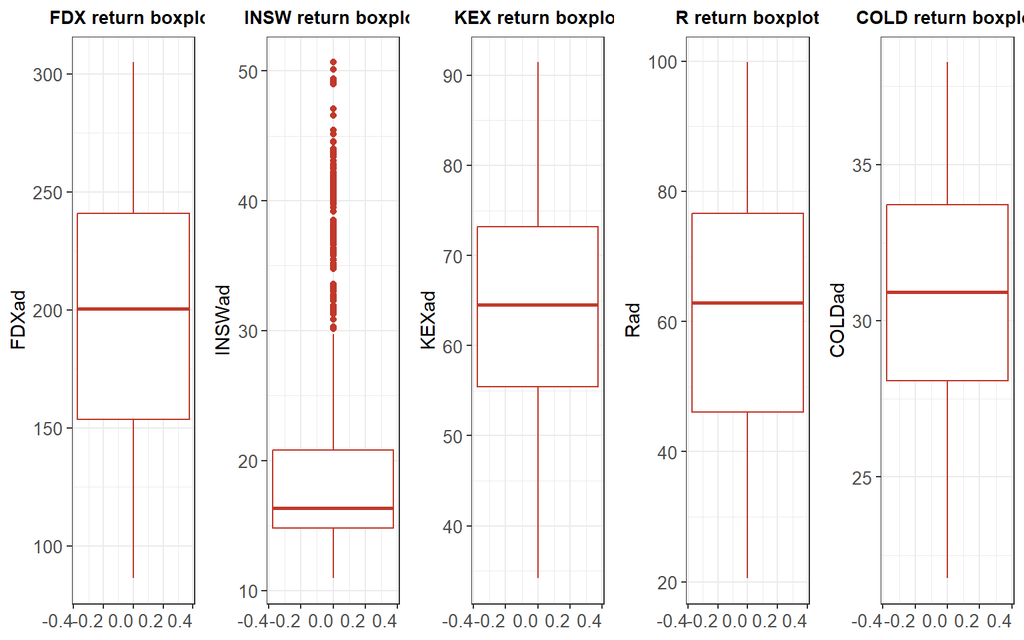

```r
box1<-ggplot(FDXad, aes(FDXad)) +
  geom_boxplot(col = '#C0392B') +
  xlab("FDXad")+coord_flip() +
  theme_bw() +
  labs(title = "FDX return boxplot") +
  theme(axis.text = element_text(size=10,hjust=1),
        axis.title.x = element_text(size=10),
        plot.title = element_text(size=10,face="bold",hjust = 0.5),
        legend.key.size = unit(1, 'cm'))
box2 <-ggplot(INSWad, aes(INSWad)) +
  geom_boxplot(col = '#C0392B') +
  xlab("INSWad")+coord_flip() +
  theme_bw() +
  labs(title = "INSW return boxplot") +
  theme(axis.text = element_text(size=10,hjust=1),
        axis.title.x = element_text(size=10),
        plot.title = element_text(size=10,face="bold",hjust = 0.5),
        legend.key.size = unit(1, 'cm'))
box3 <-ggplot(KEXad, aes(KEXad)) +
  geom_boxplot(col = '#C0392B') +
  xlab("KEXad")+coord_flip() +
  theme_bw() +
  labs(title = "KEX return boxplot") +
  theme(axis.text = element_text(size=10,hjust=1),
        axis.title.x = element_text(size=10),
        plot.title = element_text(size=10,face="bold",hjust = 0.5),
        legend.key.size = unit(1, 'cm'))
box4 <-ggplot(Rad, aes(Rad)) +
  geom_boxplot(col = '#C0392B') +
  xlab("Rad")+coord_flip() +
  theme_bw() +
  labs(title = "R return boxplot") +
  theme(axis.text = element_text(size=10,hjust=1),
        axis.title.x = element_text(size=10),
        plot.title = element_text(size=10,face="bold",hjust = 0.5),
        legend.key.size = unit(1, 'cm'))
box5 <-ggplot(COLDad, aes(COLDad)) +
  geom_boxplot(col = '#C0392B') +
  xlab("COLDad")+coord_flip() +
  theme_bw() +
  labs(title = "COLD return boxplot") +
  theme(axis.text = element_text(size=10,hjust=1),
        axis.title.x = element_text(size=10),
        plot.title = element_text(size=10,face="bold",hjust = 0.5),
        legend.key.size = unit(1, 'cm'))
grid.arrange(box1,box2,box3,box4,box5,ncol=5)
```

There are boxplots of these stocks, which show us the distribution of the adjusted price of each. We can see that the mean and median value of stock FDX, KEX, R, and COLD are equivalent, implying that the values are very evenly distributed. However, stock INSW has a huge number of outliers, and the mean and median value deviate closer to the minimum value, show us that the price of this stock in the period of 2019-2023 is usually not high.

#### Histogram

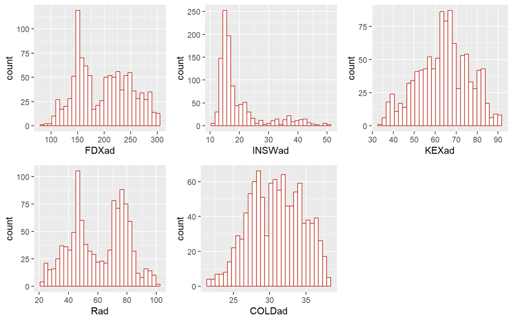

```r
# FDX, INSW, KEX, R, COLD
h1<-ggplot(FDXad, aes(x=FDXad))+
  geom_histogram(color="#C0392B", fill="white")
h2<-ggplot(INSWad, aes(x=INSWad))+
  geom_histogram(color="#C0392B", fill="white")
h3<-ggplot(KEXad, aes(x=KEXad))+
  geom_histogram(color="#C0392B", fill="white")
h4<-ggplot(Rad, aes(x=Rad))+
  geom_histogram(color="#C0392B", fill="white")
h5<-ggplot(COLDad, aes(x=COLDad))+
  geom_histogram(color="#C0392B", fill="white")

grid.arrange(h1,h2,h3,h4,h5,ncol=3, nrow=2)
```

As earlier analysis, INSW is skewed to the right and has more extreme values than a normal distribution. The tallest clusters of bars are from 13-16, indicating this price appears most frequently. The price of this stock is volatile, the frequency of high price from 40-50 for it is much lower. Meanwhile, the peak in FDX histogram is 150 USD, and it is very equally distributed from mean to high price. Only at low price the distribution is lower, so this stocks could be a safe stock. The three stocks KEX, R, COLD all have high distribution in high price. But KEX, and COLD is more centralized, the price visually is closest to normal distribution than other stocks. That is why we mentioned that risk of KEX and COLD individually are lower.

### b. Cumulative Daily Return

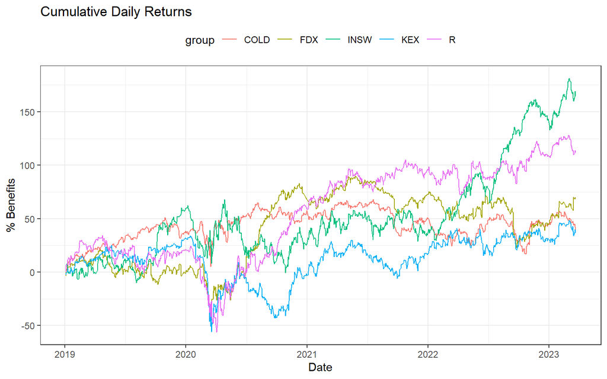

```r
# Remove first term of the series, with [-1,],
# compute rate of benefits or returns from a given time series x
# use quantmod's function Delt(x)
fdxCum = cumsum((Delt(FDXad)*100)[-1,])
inswCum = cumsum((Delt(INSWad)*100)[-1,])
kexCum = cumsum((Delt(KEXad)*100)[-1,])
rCum = cumsum((Delt(Rad)*100)[-1,])
coldCum = cumsum((Delt(COLDad)*100)[-1,])

# Create a new data frame with columns for each variable
cum_returns_data <- merge(fdxCum, inswCum, kexCum,
          rCum, coldCum)

# since df is not a dataframe, it is an xts object
# so we need a dataframe for these stocks to serve further purposes.
my_df <- data.frame(Date = index(cum_returns_data),
                    Value = coredata(cum_returns_data))

colnames(my_df) <- c('date','FDX','INSW','KEX', 'R','COLD')

draw_df <- data.frame(x = my_df$date,                # Reshape data frame
                  y = c(my_df$FDX, my_df$INSW, my_df$KEX,
                        my_df$R, my_df$COLD),
                  group = c(rep("FDX", nrow(my_df)),
                            rep("INSW", nrow(my_df)),
                            rep("KEX", nrow(my_df)),
                            rep("R", nrow(my_df)),
                            rep("COLD", nrow(my_df))
                            ))

ggplot(draw_df, aes(x = x, y = y, color = group)) +
  geom_line() +
  xlab("Date") +
  ylab("% Benefits") +
  ggtitle("Cumulative Daily Returns") +
  theme_bw() +
  theme(legend.position = "top")
```

In general, stocks with cumulative returns are up compared to the beginning of 2019. All stocks have very low returns around 2020, during the COVID-19 pandemic outbreak. However, only 2 codes with accumulated profits greater than 0% were COLD and INSW, the rest all dropped very deeply. Going through that difficult period is recovery time, seeing stocks with increased profits is very encouraging. Here we will see the separation of the two groups very clearly. INSW and R are two stocks with growth exceeding 100%, while the remaining stocks only have a growth rate of around 50%. It can be seen that INSW is a very good stock, less affected by the pandemic and even growing strongly in the post-COVID 19 period. R is also a very interesting stock, as its growth bottomed out in early 2020 but has since rebounded strongly and has grown beyond 100% by early 2023. We’ll be paying a lot of attention with these two stocks in our portfolio.

# D. PORTFOLIO OPTIMIZATION

In this section we will calculate the different cases of the portfolio. Here we only consider the case of investment, not counting the cases of selling off stocks. Therefore, the weight of each stock in the portfolio will be in the range from 0 to 1. After calculating the results, we will focus on 3 important indicators: risk, profit and weight. We have the formula:

**E(p)** = **W1** * **R1** + **W2** * **R2** +…+ **Wn** * **Rn**

The expected return can be calculated with a product of potential outcomes (returns which is represented by **r**) by the weights of each asset in the portfolio (represented by **w**), and after that calculating the sum of those results. The return and risk of the portfolio are the “mean” and “Cov” part respectively. Risk budgeting is a type of portfolio allocation in which the risk of a portfolio is distributed among different asset classes with the goal of maximizing the total return of the portfolio while keep total portfolio risk to a minimum. The weighted return is the expected return of each stock in a particular case. All of them will be represented by a pie chart below the results.

We make a table consist of daily returns of each stock (FDX, INSW, KEX, R & COLD) within the time period we present above. And then we calculate various portfolios algorithm below to explore many options for investors to choose from while all minimize the risks in different ways

## 1. Feasible Portfolio - EQUAL WEIGHTS PORTFOLIO

A feasible portfolio is an ‘existing’ portfolio described by the settings of the portfolio specification. ‘Existing’ means that the portfolio was specified by its parameters in such a way that in a risk versus return plot the portfolio has a solution and is part of the feasible set (including the efficient frontier and the minimum variance locus). In this case, we calculate with equally weighted stocks.

```r
fdx= periodReturn(FDX,period="daily",type="log")
insw= periodReturn(INSW,period="daily",type="log")
kex= periodReturn(KEX,period="daily",type="log")
r= periodReturn(R,period="daily",type="log")
cold= periodReturn(COLD,period="daily",type="log")

dailyreturn_dat <- merge(fdx, insw, kex, r, cold)
colnames(dailyreturn_dat) <- c('FDX','INSW','KEX', 'R','COLD')

head(dailyreturn_dat)
```

```
##                     FDX         INSW           KEX            R         COLD
## 2019-01-02  0.029034385  0.055763631  0.0288101130 0.0348133541 -0.014342915
## 2019-01-03 -0.037459901  0.005071862 -0.0202147346 0.0010238559  0.006400022
## 2019-01-04  0.045029628  0.053090386  0.0101584533 0.0588170888  0.014645067
## 2019-01-07  0.013890808  0.018484867  0.0128481867 0.0107486830  0.008607213
## 2019-01-08  0.001737876 -0.007353079  0.0002933685 0.0003817713  0.029176734
## 2019-01-09  0.021149404 -0.029421700  0.0280608954 0.0400277663 -0.002272690
```

```r
final_data <- as.timeSeries(100 * dailyreturn_dat[, 1:5])
```

For diversification, performance, simplicity and fairness, the equal weights portfolio is the great choice for many people.

```r
ewSpec <- portfolioSpec()
nAssets <- ncol(dailyreturn_dat)
setWeights(ewSpec) <- rep(1/nAssets, times = nAssets)

ewPortfolio <- feasiblePortfolio(
  data = final_data,
  spec = ewSpec,
  constraints = "LongOnly")

print(ewPortfolio)
```

```
##
## Title:
##  MV Feasible Portfolio
##  Estimator:         covEstimator
##  Solver:            solveRquadprog
##  Optimize:          minRisk
##  Constraints:       LongOnly
##
## Portfolio Weights:
##  FDX INSW  KEX    R COLD
##  0.2  0.2  0.2  0.2  0.2
##
## Covariance Risk Budgets:
##    FDX   INSW    KEX      R   COLD
## 0.1893 0.2343 0.2316 0.2255 0.1194
##
## Target Returns and Risks:
##   mean    Cov   CVaR    VaR
## 0.0359 1.8754 4.2693 2.8368
##
## Description:
##  Tue Apr  4 23:27:28 2023 by user: DELL
```

The output first reports the settings, then the portfolio weights, then the covariance risk budgets, and finally the target returns and risks. This includes the portfolio mean, and several portfolio risk measures, including the variance computed from the covariance matrix, the conditional value-at-risk, and the value-at-risk.

The portfolio has the target return is 0.0359 and risk is 1.8754. We will see the weight, profit of each stock contributed to the portfolio and risk of each shares clearly in the following pie chart:

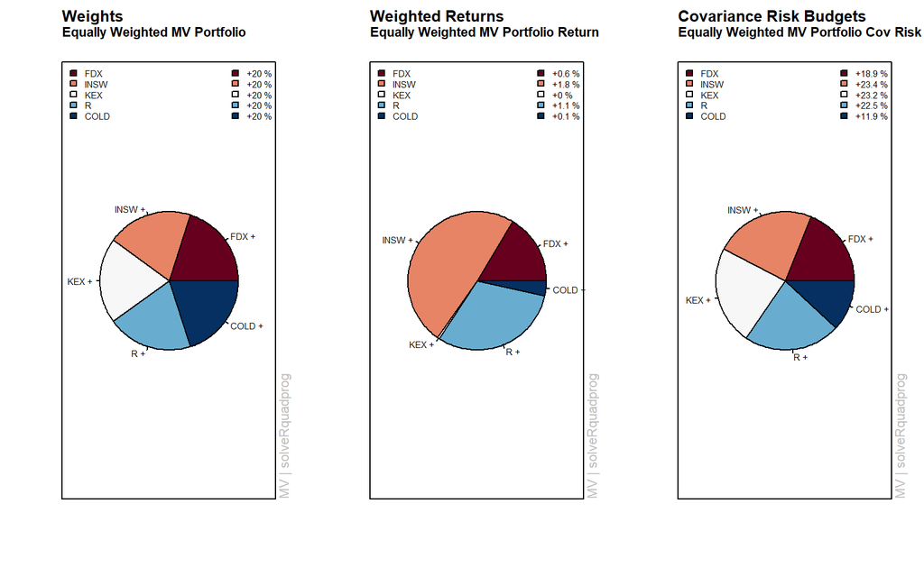

```r
nf <- layout( matrix(c(1,2,3), ncol=3) )
col <- divPalette(ncol(final_data), "RdBu")
weightsPie(ewPortfolio, radius = 0.7, col = col)
mtext(text = "Equally Weighted MV Portfolio", side = 3, line = 1.5,
font = 2, cex = 0.7, adj = 0)

weightedReturnsPie(ewPortfolio, radius = 0.7, col = col)
mtext(text = "Equally Weighted MV Portfolio Return", side = 3, line = 1.5,
font = 2, cex = 0.7, adj = 0)

covRiskBudgetsPie(ewPortfolio, radius = 0.7, col = col)
mtext(text = "Equally Weighted MV Portfolio Cov Risk", side = 3, line = 1.5,
font = 2, cex = 0.7, adj = 0)
```

The stock INSW has the highest return almost twice as high as the 2nd most profitable stock, R with 1.1%, while the smallest is KEX with 0%. However, INSW is the highest risk stock with covariance risk budgets equal 23.4%, followed by KEX stock with a risk of 23.2%. The lowest risk stock is COLD, which is almost half of INSW(11.9%)

## 2. MINIMUM RISK EFFICIENT PORTFOLIO

```r
minriskSpec <- portfolioSpec()
# targetReturn <- 0.1
targetReturn <- getTargetReturn(ewPortfolio@portfolio)["mean"]
setTargetReturn(minriskSpec) <- targetReturn

minriskPortfolio <- efficientPortfolio(
data = final_data,
spec = minriskSpec,
constraints = "LongOnly")

print(minriskPortfolio)
```

```
##
## Title:
##  MV Efficient Portfolio
##  Estimator:         covEstimator
##  Solver:            solveRquadprog
##  Optimize:          minRisk
##  Constraints:       LongOnly
##
## Portfolio Weights:
##    FDX   INSW    KEX      R   COLD
## 0.1932 0.2132 0.0000 0.1590 0.4347
##
## Covariance Risk Budgets:
##    FDX   INSW    KEX      R   COLD
## 0.1881 0.2582 0.0000 0.1714 0.3823
##
## Target Returns and Risks:
##   mean    Cov   CVaR    VaR
## 0.0359 1.7318 3.8857 2.5568
##
## Description:
##  Tue Apr  4 23:27:29 2023 by user: DELL
```

A minimum risk efficient portfolio is a portfolio with the lowest risk for a given target return. We calculate the efficient mean-variance portfolio with the same target return as the equal weights portfolio, but with the lowest possible risk.

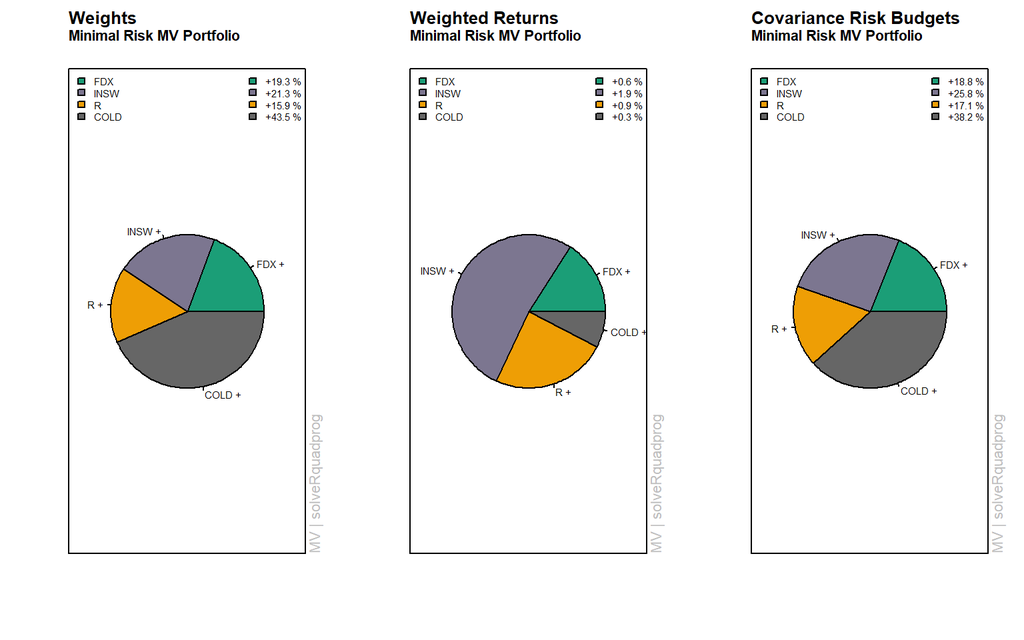

```r
nf <- layout( matrix(c(1,2,3), ncol=3) )
col <- qualiPalette(ncol(final_data), "Dark2")
weightsPie(minriskPortfolio, radius = 0.7, col = col)
mtext(text = "Minimal Risk MV Portfolio", side = 3, line = 1.5,
font = 2, cex = 0.7, adj = 0)

weightedReturnsPie(minriskPortfolio, radius = 0.7, col = col)
mtext(text = "Minimal Risk MV Portfolio", side = 3, line = 1.5,
font = 2, cex = 0.7, adj = 0)

covRiskBudgetsPie(minriskPortfolio, radius = 0.7, col = col)
mtext(text = "Minimal Risk MV Portfolio", side = 3, line = 1.5,
font = 2, cex = 0.7, adj = 0)
```

VaR = 2.556, this minRisk portfolio definitely minimize the risk of the portfolio, even low risk than equalWeight portfolio.

With highest return belongs to INSW (+1.9%), and the lowest by COLD(+0.3%). However two stocks are offset by their weights with COLD, the highest weight (+43.5%) and INSW, not so low (+21.3%). In risk budget section, COLD contributes the most risk(+38.2%) while the lowest risk seems to be R(+17.1%)

## 3. GLOBAL MINIMUM VARIANCE PORTFOLIO

The global minimum variance portfolio is the efficient portfolio with the lowest possible risk. The global minimum variance point is thus the point which separates the efficient frontier from the minimum variance locus. Internally, the global minimum mean-variance portfolio is calculated by minimizing the efficient portfolio with respect to the target risk. This is a quadratic optimization problem with linear constraints

```r
minVarSpec <- portfolioSpec()
minVarPortfolio <- minvariancePortfolio(
  data = final_data,
  spec = minVarSpec,
  constraints = "LongOnly")
print(minVarPortfolio)
```

```
##
## Title:
##  MV Minimum Variance Portfolio
##  Estimator:         covEstimator
##  Solver:            solveRquadprog
##  Optimize:          minRisk
##  Constraints:       LongOnly
##
## Portfolio Weights:
##    FDX   INSW    KEX      R   COLD
## 0.2008 0.1342 0.0610 0.0834 0.5205
##
## Covariance Risk Budgets:
##    FDX   INSW    KEX      R   COLD
## 0.2008 0.1342 0.0610 0.0834 0.5205
##
## Target Returns and Risks:
##   mean    Cov   CVaR    VaR
## 0.0256 1.7011 3.8952 2.3737
##
## Description:
##  Tue Apr  4 23:27:29 2023 by user: DELL
```

The portfolio target return in this case is 0.0256, while the risks is 1.7011. The pie chart below will show us more clearly about the weight, return of each stock contributed to the portfolio and risk of the portfolio.

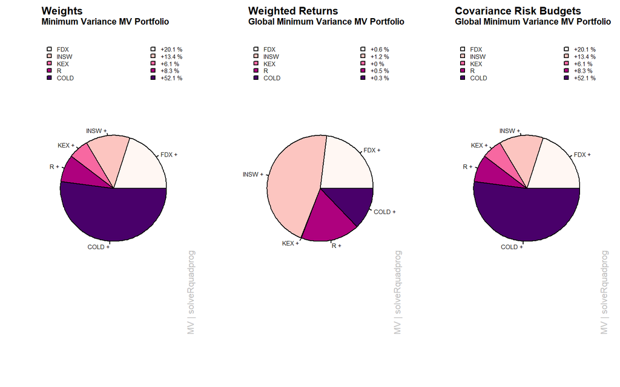

```r
nf <- layout( matrix(c(1,2,3), ncol=3) )
# RdPu
col <- seqPalette(ncol(final_data), "RdPu")
weightsPie(minVarPortfolio, box = FALSE, col = col)
mtext(text = "Minimum Variance MV Portfolio", side = 3,
line = 1.5, font = 2, cex = 0.7, adj = 0)

weightedReturnsPie(minVarPortfolio, box = FALSE, col = col)
mtext(text = "Global Minimum Variance MV Portfolio", side = 3,
line = 1.5, font = 2, cex = 0.7, adj = 0)

covRiskBudgetsPie(minVarPortfolio, box = FALSE, col = col)
mtext(text = "Global Minimum Variance MV Portfolio", side = 3,
line = 1.5, font = 2, cex = 0.7, adj = 0)
```

## 4. TANGENCY PORTFOLIO

We need the risk free rate to calculate in this portfolio. Researching shows that the interest for the US treasury bond in 10 years is 3.48%. Therefore, we take the risk free rate at 3.48%

The tangency portfolio is calculated by minimizing the Sharpe Ratio for a given risk-free rate. The Sharpe ratio is the ratio of the target return lowered by the risk-free rate and the covariance risk. We need the risk free rate to calculate in this portfolio. Researching shows that the interest for the US treasury bond in 10 years is 3.48%. Therefore, we take the risk free rate at 3.48%

```r
tgSpec <- portfolioSpec()
setRiskFreeRate(tgSpec) <- 0.0348

tgPortfolio <- tangencyPortfolio(
  data = final_data,
  spec = tgSpec,
  constraints = "LongOnly")
print(tgPortfolio)
```

```
##
## Title:
##  MV Tangency Portfolio
##  Estimator:         covEstimator
##  Solver:            solveRquadprog
##  Optimize:          minRisk
##  Constraints:       LongOnly
##
## Portfolio Weights:
##    FDX   INSW    KEX      R   COLD
## 0.0000 0.7839 0.0000 0.2161 0.0000
##
## Covariance Risk Budgets:
##    FDX   INSW    KEX      R   COLD
## 0.0000 0.9049 0.0000 0.0951 0.0000
##
## Target Returns and Risks:
##   mean    Cov   CVaR    VaR
## 0.0807 2.8615 6.3509 4.4272
##
## Description:
##  Tue Apr  4 23:27:29 2023 by user: DELL
```

We can see that compared to other cases, Tangency portfolio has the highest return at 0.0807, but also highest risk (2.8615). The weights as well as the risk of each stock are shown in the pie charts below:

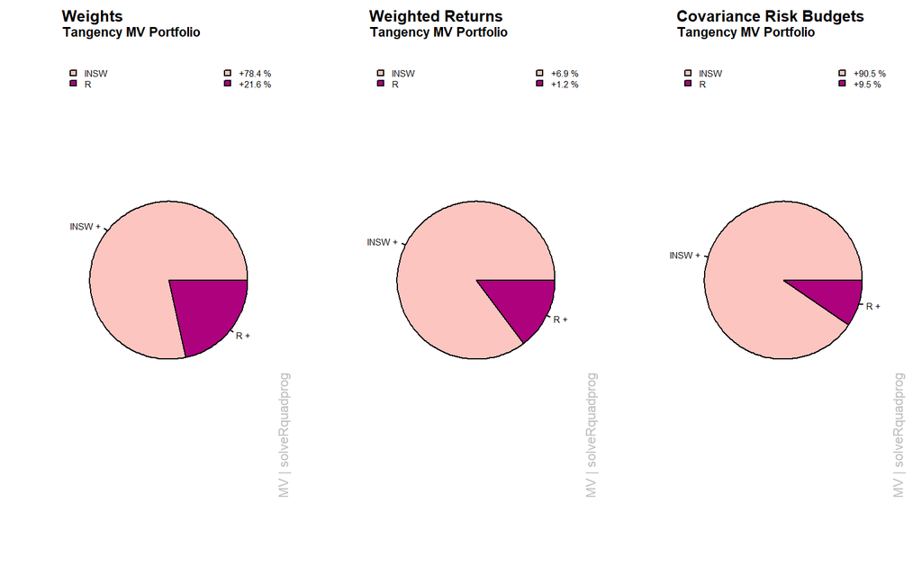

```r
nf <- layout( matrix(c(1,2,3), ncol=3) )
col <- seqPalette(ncol(final_data), "RdPu")
weightsPie(tgPortfolio, box = FALSE, col = col)
mtext(text = "Tangency MV Portfolio", side = 3, line = 1.5,
font = 2, cex = 0.7, adj = 0)

weightedReturnsPie(tgPortfolio, box = FALSE, col = col)
mtext(text = "Tangency MV Portfolio", side = 3, line = 1.5,
font = 2, cex = 0.7, adj = 0)

covRiskBudgetsPie(tgPortfolio, box = FALSE, col = col)
mtext(text = "Tangency MV Portfolio", side = 3, line = 1.5,
font = 2, cex = 0.7, adj = 0)
```

Surprisingly, there are 3 stocks without weight, of which INSW has the highest weight, accounting for more than 3/4 of the total portfolio, followed by R shares with 21.6%. This is also understandable when INSW’s profit which contributed to the portfolio is very high (6.9%), nearly 6 times higher than R. Therefore, the risk that INSW brings is also very large, 90.5%, almost 10 times higher than R.

## 5. PORTFOLIO FRONTIER

Things we need to take into consideraton about efficient frontier The efficient frontier is the idea of how investors aim to create a portfolio that maximizes expected returns based on a specific level of risk. It helps investors understand the potential risks and returns in their portfolios and analyze how they compare to the optimal set of portfolios that are considered to be efficient. Doing so helps investors to change their investing strategies by understanding the level of risk that resides in each portfolio.

It should be noted that there is no single efficient frontier for everyone. Each one is different because it depends on multiple factors. Such as the number of stocks in the portfolio, the industry of the stocks, and the degree of the investor’s risk tolerance.

The efficient frontier may not accurately portray realistic situations. For example, it assumes that all investors think rationally and avoid risks, fluctuations in market prices independent from the number of investors, and enjoy equal access to borrow money at a risk-free interest rate.

Such assumptions are not always true in real world when some investors make irrational decisions, and some investors are high risk-takers. Not all investors obtain equal access to borrowing money as well. And stock prices flunctuate due to investors behavior.

Additionally, it assumes that asset returns result in a normal distribution. However, in reality, asset returns often do not follow a normal distribution, as it often varies three standard deviations away from the mean.

[figure not shown]

```r
frontierSpec <- portfolioSpec()

setNFrontierPoints(frontierSpec) <- 25
longFrontier <- portfolioFrontier(final_data, frontierSpec)
tailoredFrontierPlot(object = longFrontier,
                     mText = "MV Portfolio - LongOnly Constraints",
                      risk = "Cov")
```

Red dot - MV Minimum Variance Portfolio Grey square - MV Feasible Portfolio, EqualWeight Blue dot - MV Tangency Portfolio

# E. CONCLUSION

The longest process of this whole sector analysis is to exclude stocks with high correlation with each other. In the end we got FDX, INSW, KEX, R & COLD to explore multiple portfolio options from the lowest risk portfolio to more high return options.

Since our group chose some of the best stocks with high market capitalization at the most active stock page, then risk would not be soaring high. Unlike other high return, high risk stocks, if those stocks experience market recession, their firm is not doing well or external forces such as disaster, pandemic especially covid-19,etc some firms will lose its foot in the industry and cancel their stocks in the public, most of the investors will get their money back but the opportunity costs would be high since they can be investing other more secure stocks that would fed them returns.